# Post-Post meeting notes ...

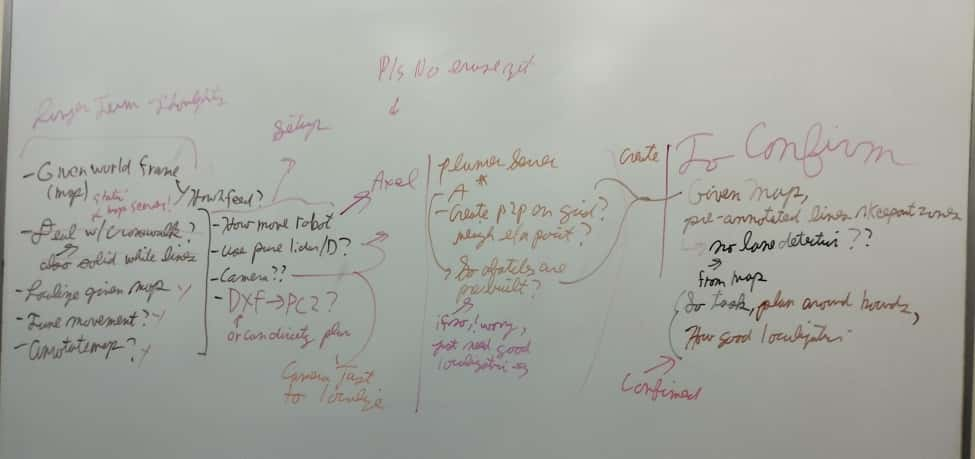

## Project details ...

Given a pre-planned map, with keepout zones AND traversable terane (between lines), make robot go from point A to B as fast as possible. This will b the "control" for the expirement, (what% of the RL model can go compared to this model).

- Likely going to use the Lidar + depth camera(as laser) for localization (maybe use MCL or VIO)
- Once localized, we can then easily get frm pt A->B, but need to ensure that localization is fairly on point
  - It would be nice to compare the localization with all the sensors
    - How many times cross line for given waypoint?
    - How are turns deviating
- Still need to decide what to use for **Planner Server**
- **Map** server likely use octomap?

## Todos ...

- How I'm moving robot
  - Has odom topic?
- Use what for localization
- Read map into pointcloud2 or something else?
- How do I serve the map? (mapserver)
- Am I using the camera for localization? (Is it possible?)

# meeting notes ...

- Make some path planner algo
- End of sem would b v cool 2 hv all these starts, then compare each of them & put em in a table (diff tech for e/a autonav manuver assumptions)

## By end of sem, have all 3 of these, then compare their metrics (Roadmap) ...

1. Assume have world model, just have A* + PID, NPC (optinal) pre built trajectory - Removed
2. Assume only local path planner, given camera from the image figure out where
   1. Based on image processing, based on whr u r + whr is goal wrt u, how can plan without lane collision (counts as an object)
   2. Cross walk???? (tf)
   3. The solid horizontal white line, detectable? How??
3. Using RL, still plang the path but local only, try 2 make sure ! far frm optimal path. DOnt deviate frm the pre planned path
   1. For RL, just move directly to goal
   2. Create an easy world model, then update it slowly as needed

Let Dr Haibi know what data you need frm her side, just focus on the NUC an the car.

- Go look at the minictiy review to see everythug you need to accounnt for with this stuff

For now with urs:

- Basically how fast can we go in between the lines (wee), will have sharp turns etc etc, very basic autonav stuff. In a month, which one is the most doable?

Our case, more right angle, intersection, More of a question how how we can transf the model. For start, we just need to worry about minicty. Add a slight bit of noise.

### Who is doing what ...

- Aaron: look at camera resolution
- start implementing some of these things

### Arika: ...

Known world frame, Use all sensors avail to you, fastest course completion,

- Directly works on the car
- If see other ways, or diffrerent appraoch to get similar results to get the same goal
- You're doing the first option! Just use some particle filter, create another map manually the road map (its somewhere for the sim)
  - Already know whr everything is, js use some simple path planner
  - Should be done in about 10 days
- Obtain the currently map, u can use the lidar if u really wan
- Extern add some roadmap
- Basically how fast can u get the robot to finish the course??
- Think about trajectory generation?
- You can use lidar for localization! (Unusre how easy for map created by lidar)
  - From previpous work, see that visual combine with IMU, usually VIO gives rly good
- Both can use odem!
- NPC likely takes 2 weeks, other 2 items should only take 2 weeks

## Followup qns ...

- Do I have a sdf robot file to work on or need to create myself? (Do I NEED one? I could really just localize via the caemra/pc2 and create a very basic turtle bot thats 2d)
  - I liekly want to make the robot slightly smaller than it actually is

Have map (already have): Work on particle filter (how do we localize in the given map), given w/ rviz. Then after can localize, then throw up a ros2 package! Same with NPC for package

# Slides ...

## Project updates ...

Regarding lane detection:

- Will take a look at SCR's code and likely use about the same logic (but just in a RL model), exporting each frame as a greyscale,
  - Major drawback which would be nice to consider (espically if I want to implement it for selfdrive in SCR) is to consider dymanic light conditions, however can likely simualte all possible ones in unity
- Looking at Aarons suggestion of Ultra-Fast-Lane-Detection

## Things I'm reading up on ...

- Still havent fully looked up the repo things
- reading up on [Unity Machine Learning Agents Toolkit](https://github.com/Unity-Technologies/ml-agents)
- Looked at another example with RL in unity sim [here](https://flyyufelix.github.io/2018/09/11/donkey-rl-simulation.html)

## Other updates ...

- Logged into website, emailed Gladis for short info script, get talent form, and picture (optional).
  - **Confirm members to mark as alumni**
- FRANCIS project is going OK. Having trouble generating global waypointing, deciding how to proceed currently
  - Issue: LIDAR takes in 15V via 3.5mm barrel jack, however unsure how to power it (use small rig?). Ordering a 3.5mm barrel jack to usb-c may not sovle our issue. Thinking of order a Barrel Male Plug Connector Pigtail
  - Trying to get the GNSS waypointing example working in time. However I will need to feed the pointcloud data into a map server, liekly using [octomap2](https://github.com/iKrishneel/octomap_server2)

## Misc Interesting things I've run into ...

- Found an interesting interactive [paper](https://accelagent.github.io/) on generating training enviorments for agents with reinforcement learning
- I normally use my obsidan vault for everything, however I never really wanted to pay to publish a site using my vault. I've found [Quartz 4](https://quartz.jzhao.xyz/), which plugs directly into my vault. This would be nice if I ever wanted to overhaul our wiki, or generate documentation on a large project using markdown.
  - This was found from a website [here](https://stevengong.co/notes/Camera-Calibration) which seems to have A LOT of very well documented notes on robotics.